# Dimention reduction

## Descriptions on the data

The data is a joined data set of Human Development Index and Gender Development Index that is originated from the United Nations Development Programme’s website. Source of the data: http://hdr.undp.org/en/content/human-development-index-hdi.  
The data has the following variables:

1. hdirank = HDI ranking for countries
2. Country = Country name
3. hdi = Human Development Index (HDI)
4. lifeexp = Life expectancy at birth
5. expedu = Expected years of schooling
6. meanedu = Mean years of schooling
7. gni = Gross National Income (GNI) per capita
8. gni-hdi = GNI per capita rank minus HDI rank
9. giirank = GII ranking for countries
10. gii = Gender Inequality Index (GII)
11. matmor = Maternal mortality ratio
12. adobirth = Adolescent birth rate
13. repparl = Percetange of female representatives in parliament
14. edu2F = Proportion of females with at least secondary education
15. edu2M = Proportion of males with at least secondary education
16. labfF = Proportion of females in the labour force
17. labfM = Proportion of males in the labour force
18. edu2FM - the ratio of Female and Male populations with secondary education in each country (2eduF / 2eduM)
19. labfFM = the ratio of labour force participation of females and males in each country (labfF / labfM).

```r
data <- read.table("C:/R scripts/IODS-project/data/human.csv")

library(tidyr)
library(dplyr)
library(ggplot2)
library(GGally)
library(corrplot)

summary (data)
```

```
##      edu2FM           labfFM         lifeexp         expeedu
##  Min.   :  2.05   Min.   :40.90   Min.   :49.00   Min.   : 5.40
##  1st Qu.: 33.27   1st Qu.:56.65   1st Qu.:66.30   1st Qu.:11.25
##  Median : 56.95   Median :63.40   Median :74.20   Median :13.50
##  Mean   : 58.03   Mean   :63.45   Mean   :71.65   Mean   :13.18
##  3rd Qu.: 86.65   3rd Qu.:69.30   3rd Qu.:77.25   3rd Qu.:15.20
##  Max.   :100.00   Max.   :89.15   Max.   :83.50   Max.   :20.20
##       gni             matmor          adobirth         repparl
##  Min.   :   581   Min.   :   1.0   Min.   :  0.60   Min.   : 0.00
##  1st Qu.:  4198   1st Qu.:  11.5   1st Qu.: 12.65   1st Qu.:12.40
##  Median : 12040   Median :  49.0   Median : 33.60   Median :19.30
##  Mean   : 17628   Mean   : 149.1   Mean   : 47.16   Mean   :20.91
##  3rd Qu.: 24512   3rd Qu.: 190.0   3rd Qu.: 71.95   3rd Qu.:27.95
##  Max.   :123124   Max.   :1100.0   Max.   :204.80   Max.   :57.50
```

The variables in the data have different scales. Below we can see some graphic overview of the dataset.  
Correlations:  
1) Positive:  
- lifeexp and edu2FM (r = 0.710), a large correlation shows that in countries with beigger life expectancy at birth there is begger ratio of Female and Male populations with secondary education  
- expeedu and edu2FM (r = 0.778), the correlation shows that the bigger expected years of schooling, the bigger ratio of Female and Male populations with secondary education  
- gni and eduFM (0.542), a moderate correlation shows that in countries with bigger Gross National Income (GNI) per capita there is bigger ratio of Female and Male populations with secondary education  
- expeedu and lifeexp (r = 0.789), a large correlation shows that in countries with bigger Expected years of schooling, life expectancy at birth is bigger  
- gni and lifeexp (r = 0.627), a moderate correlation shows that in countries that have bigger Gross National Income (GNI) per capita, life expectancy at birth is higher  
- adobirth and matmor (r = 0.759), the large association shows that in countries with higher Adolescent birth rate, Maternal mortality ratio is higher

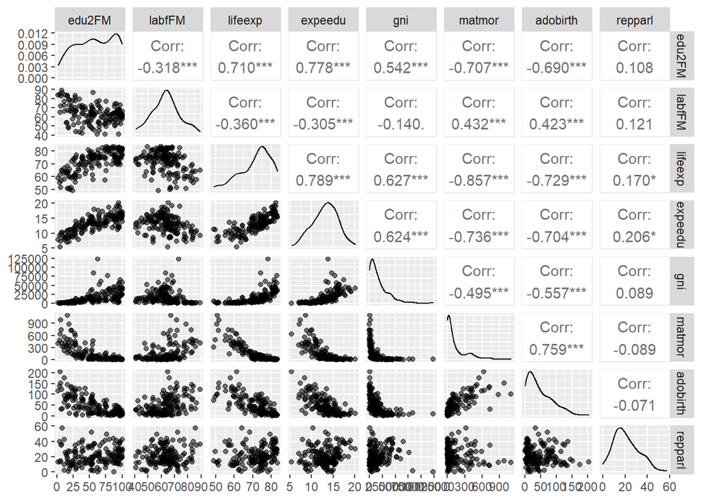

```r
ggpairs(data, mapping = aes(alpha=0.3), lower = list(combo = wrap("facethist", bins = 20)))
```

## Principal component analysis (PCA) Firstly, the PCA is perfomed with not standartizied data.

```r
# perform principal component analysis (with the SVD method)
PCA_1 <- prcomp(data)

s1 <-summary(PCA_1)
s1
```

```
## Importance of components:
##                              PC1      PC2  PC3  PC4   PC5   PC6   PC7   PC8
## Standard deviation     1.854e+04 186.1743 26.2 18.3 11.67 8.657 3.714 1.426
## Proportion of Variance 9.999e-01   0.0001  0.0  0.0  0.00 0.000 0.000 0.000
## Cumulative Proportion  9.999e-01   1.0000  1.0  1.0  1.00 1.000 1.000 1.000
```

```r
PCA_1
```

```
## Standard deviations (1, .., p=8):
## [1] 18544.170799   186.174340    26.202403    18.304196    11.665826
## [6]     8.657387     3.713783     1.425649
##
## Rotation (n x k) = (8 x 8):
##                    PC1          PC2          PC3           PC4           PC5
## edu2FM   -8.571849e-04 -0.080819610 -0.369612023 -0.9224135460  6.059960e-02
## labfFM    7.736650e-05  0.023238470  0.073933350 -0.0414552136 -3.030003e-01
## lifeexp  -2.815825e-04 -0.028243392 -0.016953743 -0.0251331185 -5.720881e-02
## expeedu  -9.562915e-05 -0.007563104 -0.020533695 -0.0339342421 -2.539794e-02
## gni      -9.999828e-01  0.005823107  0.000616372  0.0001796211  6.114001e-05
## matmor    5.655739e-03  0.988078062 -0.148612616 -0.0280034590  9.601322e-04
## adobirth  1.233962e-03  0.125421892  0.913851339 -0.3754232019  4.877079e-02
## repparl  -5.526462e-05 -0.003234070  0.001179486 -0.0626474456 -9.477453e-01
##                    PC6           PC7           PC8
## edu2FM   -1.045561e-02 -0.0320831305  0.0345933498
## labfFM   -9.487597e-01  0.0179161447 -0.0005018860
## lifeexp   3.600044e-02  0.9904926074  0.1124217211
## expeedu   1.039982e-02  0.1094101348 -0.9927969760
## gni       7.975111e-05 -0.0001048564  0.0000207890
## matmor    1.400194e-02  0.0245444218 -0.0006698197
## adobirth  7.531476e-02  0.0104901127 -0.0063270070
## repparl   3.040941e-01 -0.0699358234  0.0218652509
```

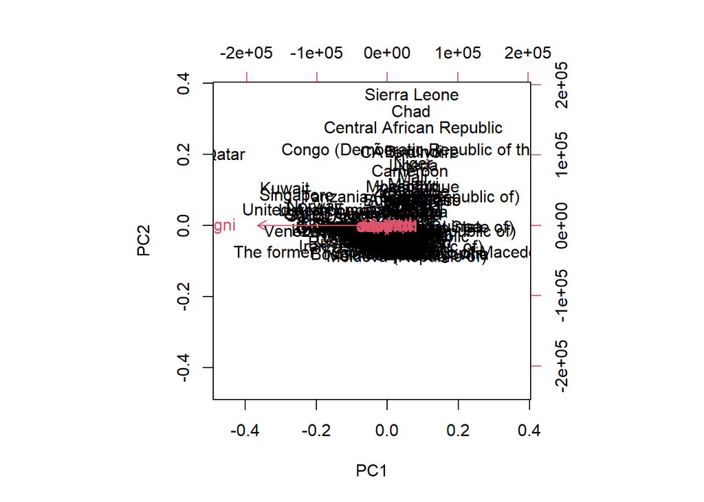

```r
biplot(PCA_1, choices = 1:2)
```

```r
# rounded percentages of variance captured by each PC
var1 <- round(100*s1$importance[2,], digits = 1)

# print out the percentages of variance
var1
```

```
## PC1 PC2 PC3 PC4 PC5 PC6 PC7 PC8
## 100   0   0   0   0   0   0   0
```

The analysis gave to us 8 dimentions, one for each variable. We can see that all the principal components are not correlated. PC1 captures the biggest variance, the every next explain less and less of variabnce. When I round persentages of variance captured by each PC, we can see that the first explains 100% of variance. On the biplot we can see the observations represented by the first two principal components along with arrows representing the original variables.

With a next step, I standartize variables and repeat the above analysis.

```r
# standardize the variables
data_sc <- scale(data)

# perform principal component analysis (with the SVD method)
PCA_2 <- prcomp(data_sc)

s2<- summary(PCA_2)
s2
```

```
## Importance of components:
##                           PC1    PC2     PC3     PC4     PC5     PC6     PC7
## Standard deviation     2.1585 1.0679 0.88106 0.68579 0.59186 0.53987 0.44297
## Proportion of Variance 0.5824 0.1426 0.09703 0.05879 0.04379 0.03643 0.02453
## Cumulative Proportion  0.5824 0.7249 0.82195 0.88074 0.92453 0.96096 0.98549
##                            PC8
## Standard deviation     0.34071
## Proportion of Variance 0.01451
## Cumulative Proportion  1.00000
```

```r
PCA_2
```

```
## Standard deviations (1, .., p=8):
## [1] 2.1584687 1.0678839 0.8810583 0.6857865 0.5918650 0.5398707 0.4429730
## [8] 0.3407058
##
## Rotation (n x k) = (8 x 8):
##                  PC1        PC2          PC3         PC4          PC5
## edu2FM   -0.39556969 0.02510493 -0.078866605  0.31220840 -0.697043736
## labfFM    0.21590149 0.57685573 -0.617756283  0.44769345  0.166725322
## lifeexp  -0.42391815 0.05251511 -0.007929215  0.08631790  0.390722065
## expeedu  -0.41413247 0.13161969 -0.059589507  0.09293514 -0.307479818
## gni      -0.32896485 0.16287028 -0.501208047 -0.74508370  0.020320217
## matmor    0.41397085 0.08372472 -0.098030180 -0.31521159 -0.440093945
## adobirth  0.40088980 0.09519879 -0.017111886 -0.06213506 -0.212104218
## repparl  -0.07346083 0.77712693  0.589432958 -0.16625266 -0.006429306
##                  PC6          PC7         PC8
## edu2FM    0.03784034 -0.496212213  0.07531214
## labfFM    0.10289515  0.009021408 -0.01027783
## lifeexp  -0.38373845 -0.074142959  0.71035611
## expeedu  -0.21625478  0.799985095 -0.13302852
## gni      -0.02434938 -0.174234770 -0.16592957
## matmor    0.20363260  0.224416684  0.65355817
## adobirth -0.86396208 -0.138030767 -0.12489920
## repparl   0.07395789 -0.091900097 -0.04061224
```

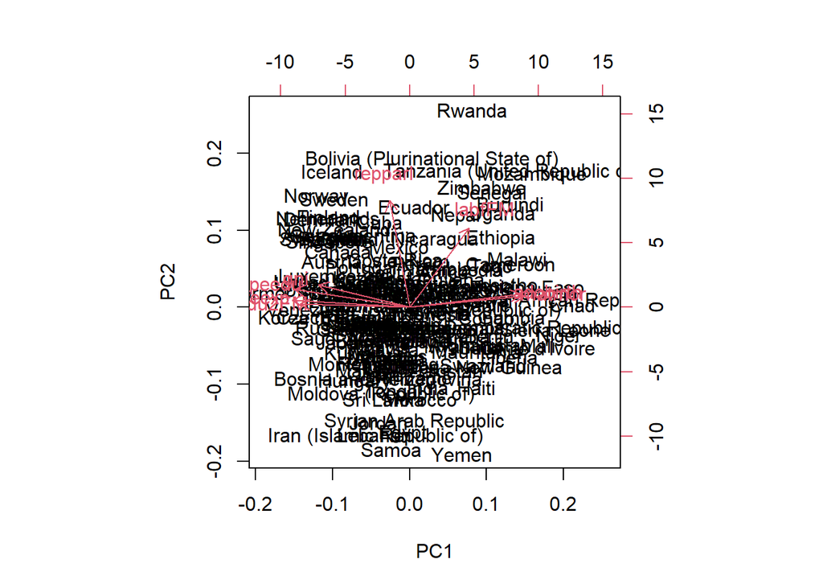

```r
biplot(PCA_2, choices = 1:2)
```

```r
# rounded percentages of variance captured by each PC
var2 <- round(100*s2$importance[2,], digits = 1)

# print out the percentages of variance
var2
```

```
##  PC1  PC2  PC3  PC4  PC5  PC6  PC7  PC8
## 58.2 14.3  9.7  5.9  4.4  3.6  2.5  1.5
```

There are few observations that I can make looking at the distribution of the countries: the rich and developed countries with good representation of men and wemen are lokated on the upper left corned (countries such as Norvay, Iceland and so on); on the lower left corner there are rich and developed countries that, however have some issues with representation of women in parliament of work places (countries like Saudi Arabia). On the right side there are countries that are less wealty: on the upper right poor countries with good women representation (Burundi); on the lower right there are poor countries with issues in women representation (Niger, Afganistan).

## Tea dataset

```r
library(FactoMineR)
data(tea)
str(tea)
```

```
## 'data.frame':    300 obs. of  36 variables:
##  $ breakfast       : Factor w/ 2 levels "breakfast","Not.breakfast": 1 1 2 2 1 2 1 2 1 1 ...
##  $ tea.time        : Factor w/ 2 levels "Not.tea time",..: 1 1 2 1 1 1 2 2 2 1 ...
##  $ evening         : Factor w/ 2 levels "evening","Not.evening": 2 2 1 2 1 2 2 1 2 1 ...
##  $ lunch           : Factor w/ 2 levels "lunch","Not.lunch": 2 2 2 2 2 2 2 2 2 2 ...
##  $ dinner          : Factor w/ 2 levels "dinner","Not.dinner": 2 2 1 1 2 1 2 2 2 2 ...
##  $ always          : Factor w/ 2 levels "always","Not.always": 2 2 2 2 1 2 2 2 2 2 ...
##  $ home            : Factor w/ 2 levels "home","Not.home": 1 1 1 1 1 1 1 1 1 1 ...
##  $ work            : Factor w/ 2 levels "Not.work","work": 1 1 2 1 1 1 1 1 1 1 ...
##  $ tearoom         : Factor w/ 2 levels "Not.tearoom",..: 1 1 1 1 1 1 1 1 1 2 ...
##  $ friends         : Factor w/ 2 levels "friends","Not.friends": 2 2 1 2 2 2 1 2 2 2 ...
##  $ resto           : Factor w/ 2 levels "Not.resto","resto": 1 1 2 1 1 1 1 1 1 1 ...
##  $ pub             : Factor w/ 2 levels "Not.pub","pub": 1 1 1 1 1 1 1 1 1 1 ...
##  $ Tea             : Factor w/ 3 levels "black","Earl Grey",..: 1 1 2 2 2 2 2 1 2 1 ...
##  $ How             : Factor w/ 4 levels "alone","lemon",..: 1 3 1 1 1 1 1 3 3 1 ...
```

[output cut: 22 more lines]

```r
dim(tea)
```

```
## [1] 300  36
```

```r
# data has 300 obs and 36 var
```

The data describes preferences of people onto how to drink tea. There are categorical and dichotomous variables, age is continious and categorical. There are data has 300 observations and 36 variables.

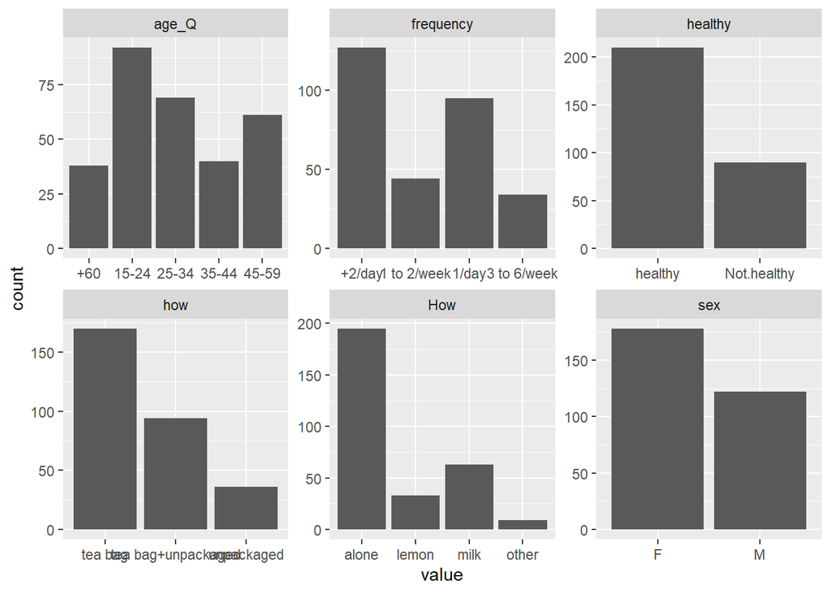

```r
keep <- c("age_Q", "sex", "How", "how", "frequency", "healthy")
tea <- dplyr::select(tea, one_of(keep))
gather(tea) %>% ggplot(aes(value)) + facet_wrap("key", scales = "free") + geom_bar()
```

Next, I will do multiple correspondence analysis and visualize it

```r
# multiple correspondence analysis
MCA <- MCA(tea, graph = FALSE)

# summary of the model
summary(MCA)
```

```
##
## Call:
## MCA(X = tea, graph = FALSE)
##
##
## Eigenvalues
##                        Dim.1   Dim.2   Dim.3   Dim.4   Dim.5   Dim.6   Dim.7
## Variance               0.244   0.224   0.212   0.198   0.191   0.178   0.173
## % of var.             10.440   9.599   9.077   8.493   8.183   7.612   7.396
## Cumulative % of var.  10.440  20.039  29.117  37.610  45.793  53.404  60.801
##                        Dim.8   Dim.9  Dim.10  Dim.11  Dim.12  Dim.13  Dim.14
## Variance               0.160   0.156   0.145   0.127   0.116   0.110   0.101
## % of var.              6.846   6.666   6.199   5.464   4.952   4.731   4.340
## Cumulative % of var.  67.647  74.313  80.512  85.976  90.928  95.660 100.000
##
## Individuals (the 10 first)
##          Dim.1    ctr   cos2    Dim.2    ctr   cos2    Dim.3    ctr   cos2
## 1     |  0.181  0.045  0.017 |  0.453  0.305  0.104 | -0.383  0.231  0.074 |
## 2     | -0.241  0.079  0.030 |  0.607  0.548  0.189 | -0.695  0.760  0.247 |
## 3     | -0.504  0.348  0.198 | -0.051  0.004  0.002 | -0.020  0.001  0.000 |
## 4     |  0.119  0.020  0.011 |  0.068  0.007  0.004 | -0.619  0.604  0.302 |
## 5     |  0.245  0.082  0.035 | -0.118  0.021  0.008 | -0.046  0.003  0.001 |
## 6     |  0.119  0.020  0.011 |  0.068  0.007  0.004 | -0.619  0.604  0.302 |
## 7     |  0.263  0.095  0.024 |  0.030  0.001  0.000 |  0.267  0.113  0.025 |
## 8     | -0.128  0.023  0.006 |  0.228  0.077  0.017 | -0.546  0.470  0.100 |
## 9     |  0.152  0.032  0.008 |  0.099  0.015  0.003 | -0.069  0.007  0.002 |
## 10    | -0.147  0.030  0.010 |  0.031  0.001  0.000 |  0.232  0.085  0.026 |
##
## Categories (the 10 first)
##           Dim.1     ctr    cos2  v.test     Dim.2     ctr    cos2  v.test
## 15-24 |  -0.369   2.851   0.060  -4.240 |  -0.878  17.597   0.341 -10.098 |
## 25-34 |   1.045  17.198   0.326   9.880 |   0.186   0.589   0.010   1.753 |
## 35-44 |  -0.186   0.315   0.005  -1.260 |   0.215   0.458   0.007   1.457 |
## 45-59 |  -0.104   0.150   0.003  -0.906 |   0.271   1.110   0.019   2.366 |
## +60   |  -0.644   3.591   0.060  -4.239 |   1.128  12.000   0.185   7.430 |
## F     |  -0.519  10.924   0.393 -10.835 |  -0.310   4.255   0.141  -6.484 |
## M     |   0.757  15.938   0.393  10.835 |   0.453   6.208   0.141   6.484 |
## alone |   0.057   0.142   0.006   1.332 |  -0.409   8.099   0.311  -9.642 |
## lemon |   0.273   0.561   0.009   1.660 |   0.519   2.207   0.033   3.156 |
## milk  |   0.000   0.000   0.000   0.001 |   0.735   8.448   0.144   6.555 |
##         Dim.3     ctr    cos2  v.test
## 15-24  -0.546   7.199   0.132  -6.281 |
## 25-34   0.148   0.394   0.007   1.395 |
## 35-44   0.106   0.117   0.002   0.716 |
## 45-59   0.005   0.000   0.000   0.046 |
## +60     0.935   8.709   0.127   6.156 |
## F       0.049   0.114   0.004   1.032 |
## M      -0.072   0.166   0.004  -1.032 |
## alone   0.052   0.137   0.005   1.219 |
## lemon   0.934   7.550   0.108   5.677 |
## milk   -0.830  11.397   0.183  -7.404 |
##
## Categorical variables (eta2)
##             Dim.1 Dim.2 Dim.3
## age_Q     | 0.352 0.427 0.209 |
## sex       | 0.393 0.141 0.004 |
## How       | 0.159 0.351 0.291 |
## how       | 0.113 0.048 0.421 |
## frequency | 0.258 0.187 0.346 |
## healthy   | 0.187 0.191 0.001 |
```

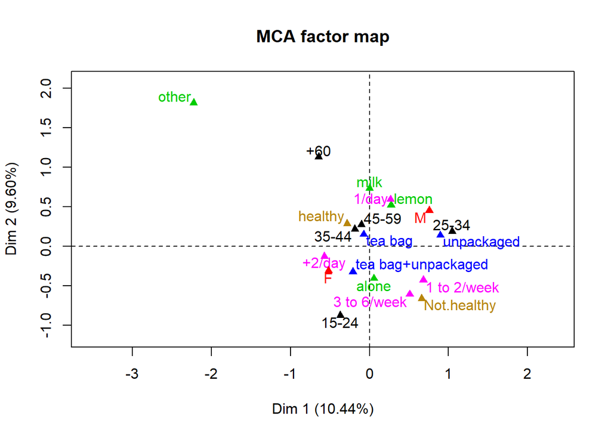

```r
# visualize MCA
plot(MCA, invisible=c("ind"), habillage = "quali", graph.type = "classic")
```

All the dimensions explain quite equal amount of variation. To explain 50% of variation we will need 6 dimensions. We are suggested to have 3 dimensions, where the first one would explain sex; second - age_Q, How; third - how, frequency; healthy is almost equaly explained by first and second clusters. Therefore, we can say that if people dring tea alone or with milk or lemon, it is correlated to age; frequency is correlated to the way people make tea (bag or not).  
The distance between the categories tells us how similar they are. Therefore, 25-34 y.o. people prefer unpackged tea 1 tim per day. The majority of 25-35 people t=whoo are drinking tea are males. Females prefer to drink tea 2 times per day and more likely to drink tea made of tea bag. People from 35 to 44 and from 45 to 59 tend to drink bag tea and believe that it is healthy to drink tea. The older people the more they tend to drink tea with lemon or milk. Also, old peopel are more likely to believe that to drink tea is healthy. Category “other” is obvious outliner.